# 00_EDA

```python
import pandas as pd
```

```python
import numpy as np
import seaborn as sns
import matplotlib.pyplot as plt

%matplotlib inline
```

```python
data =  pd.read_csv('covid.csv')
data
```

|  | AggregationMethod | Date | Version | AirportName | PercentOfBaseline | Centroid | City | State | ISO_3166_2 | Country | Geography |
| --- | --- | --- | --- | --- | --- | --- | --- | --- | --- | --- | --- |
| 0 | Daily | 2020-07-05 | 1.0 | Kingsford Smith | 52 | POINT(151.180087713813 -33.9459774986125) | Sydney | New South Wales | AU | Australia | POLYGON((151.164354085922 -33.9301772341877, 1... |
| 1 | Daily | 2020-05-28 | 1.0 | Kingsford Smith | 61 | POINT(151.180087713813 -33.9459774986125) | Sydney | New South Wales | AU | Australia | POLYGON((151.164354085922 -33.9301772341877, 1... |
| 2 | Daily | 2020-05-07 | 1.0 | Kingsford Smith | 62 | POINT(151.180087713813 -33.9459774986125) | Sydney | New South Wales | AU | Australia | POLYGON((151.164354085922 -33.9301772341877, 1... |
| 3 | Daily | 2020-06-24 | 1.0 | Kingsford Smith | 58 | POINT(151.180087713813 -33.9459774986125) | Sydney | New South Wales | AU | Australia | POLYGON((151.164354085922 -33.9301772341877, 1... |
| 4 | Daily | 2020-08-05 | 1.0 | Kingsford Smith | 20 | POINT(151.180087713813 -33.9459774986125) | Sydney | New South Wales | AU | Australia | POLYGON((151.164354085922 -33.9301772341877, 1... |
| ... | ... | ... | ... | ... | ... | ... | ... | ... | ... | ... | ... |
| 5931 | Daily | 2020-06-15 | 1.0 | Seattle-Tacoma International | 64 | POINT(-122.308661576118 47.4505828917119) | SeaTac | Washington | US-WA | United States of America (the) | POLYGON((-122.297594547272 47.434474106872, -1... |
| 5932 | Daily | 2020-10-15 | 1.0 | Seattle-Tacoma International | 74 | POINT(-122.308661576118 47.4505828917119) | SeaTac | Washington | US-WA | United States of America (the) | POLYGON((-122.297594547272 47.434474106872, -1... |
| 5933 | Daily | 2020-04-01 | 1.0 | Seattle-Tacoma International | 65 | POINT(-122.308661576118 47.4505828917119) | SeaTac | Washington | US-WA | United States of America (the) | POLYGON((-122.297594547272 47.434474106872, -1... |
| 5934 | Daily | 2020-05-12 | 1.0 | Seattle-Tacoma International | 65 | POINT(-122.308661576118 47.4505828917119) | SeaTac | Washington | US-WA | United States of America (the) | POLYGON((-122.297594547272 47.434474106872, -1... |
| 5935 | Daily | 2020-10-11 | 1.0 | Seattle-Tacoma International | 57 | POINT(-122.308661576118 47.4505828917119) | SeaTac | Washington | US-WA | United States of America (the) | POLYGON((-122.297594547272 47.434474106872, -1... |

5936 rows × 11 columns

#### Limpieza de la base de datos.

Con data shape observo que hay un total de 5936 filas y 11 columnas.

```python
data.shape
```

```
(5936, 11)
```

```python
data.describe()
```

|  | Version | PercentOfBaseline |
| --- | --- | --- |
| count | 5936.0 | 5936.000000 |
| mean | 1.0 | 65.581705 |
| std | 0.0 | 21.985070 |
| min | 1.0 | 0.000000 |
| 25% | 1.0 | 52.000000 |
| 50% | 1.0 | 66.000000 |
| 75% | 1.0 | 82.000000 |
| max | 1.0 | 100.000000 |

```python
data.head()
```

|  | AggregationMethod | Date | Version | AirportName | PercentOfBaseline | Centroid | City | State | ISO_3166_2 | Country | Geography |
| --- | --- | --- | --- | --- | --- | --- | --- | --- | --- | --- | --- |
| 0 | Daily | 2020-07-05 | 1.0 | Kingsford Smith | 52 | POINT(151.180087713813 -33.9459774986125) | Sydney | New South Wales | AU | Australia | POLYGON((151.164354085922 -33.9301772341877, 1... |
| 1 | Daily | 2020-05-28 | 1.0 | Kingsford Smith | 61 | POINT(151.180087713813 -33.9459774986125) | Sydney | New South Wales | AU | Australia | POLYGON((151.164354085922 -33.9301772341877, 1... |
| 2 | Daily | 2020-05-07 | 1.0 | Kingsford Smith | 62 | POINT(151.180087713813 -33.9459774986125) | Sydney | New South Wales | AU | Australia | POLYGON((151.164354085922 -33.9301772341877, 1... |
| 3 | Daily | 2020-06-24 | 1.0 | Kingsford Smith | 58 | POINT(151.180087713813 -33.9459774986125) | Sydney | New South Wales | AU | Australia | POLYGON((151.164354085922 -33.9301772341877, 1... |
| 4 | Daily | 2020-08-05 | 1.0 | Kingsford Smith | 20 | POINT(151.180087713813 -33.9459774986125) | Sydney | New South Wales | AU | Australia | POLYGON((151.164354085922 -33.9301772341877, 1... |

```python
data.describe(include='all').T
```

[output not shown]

```python
data.dtypes
```

```
AggregationMethod     object
Date                  object
Version              float64
AirportName           object
PercentOfBaseline      int64
Centroid              object
City                  object
State                 object
ISO_3166_2            object
Country               object
Geography             object
dtype: object
```

A continuación voy a sacar los valores únicos de cada variable para ver si hay algún dato mal escrito o que no corresponda con el resto.

```python
for i in data.columns:
    print('{} has unique values {}'.format(i,data[i].unique()),'\n')
```

[output not shown]

[output cut: 58 more lines]

[output not shown]

Voy a eliminar las variables 'Version' y 'Centroid' ya que no son relevantes para mi análisis.

```python
data = data.drop(['Version'], axis=1)
data.head(5)
```

|  | AggregationMethod | Date | AirportName | PercentOfBaseline | Centroid | City | State | ISO_3166_2 | Country | Geography |
| --- | --- | --- | --- | --- | --- | --- | --- | --- | --- | --- |
| 0 | Daily | 2020-07-05 | Kingsford Smith | 52 | POINT(151.180087713813 -33.9459774986125) | Sydney | New South Wales | AU | Australia | POLYGON((151.164354085922 -33.9301772341877, 1... |
| 1 | Daily | 2020-05-28 | Kingsford Smith | 61 | POINT(151.180087713813 -33.9459774986125) | Sydney | New South Wales | AU | Australia | POLYGON((151.164354085922 -33.9301772341877, 1... |
| 2 | Daily | 2020-05-07 | Kingsford Smith | 62 | POINT(151.180087713813 -33.9459774986125) | Sydney | New South Wales | AU | Australia | POLYGON((151.164354085922 -33.9301772341877, 1... |
| 3 | Daily | 2020-06-24 | Kingsford Smith | 58 | POINT(151.180087713813 -33.9459774986125) | Sydney | New South Wales | AU | Australia | POLYGON((151.164354085922 -33.9301772341877, 1... |
| 4 | Daily | 2020-08-05 | Kingsford Smith | 20 | POINT(151.180087713813 -33.9459774986125) | Sydney | New South Wales | AU | Australia | POLYGON((151.164354085922 -33.9301772341877, 1... |

```python
data = data.drop(['Centroid'], axis=1)
data.head(5)
```

[output not shown]

Renombro algunas de las columnas ya que pueden resultar confusas.

```python
data = data.rename(columns={'ISO_3166_2': 'Pais_Subdivision', 'PercentOfBaseline' : 'Porcentaje', 'AggregationMethod':'Periodo'})
data.head(5)
```

|  | Periodo | Date | AirportName | Porcentaje | City | State | Pais_Subdivision | Country | Geography |
| --- | --- | --- | --- | --- | --- | --- | --- | --- | --- |
| 0 | Daily | 2020-07-05 | Kingsford Smith | 52 | Sydney | New South Wales | AU | Australia | POLYGON((151.164354085922 -33.9301772341877, 1... |
| 1 | Daily | 2020-05-28 | Kingsford Smith | 61 | Sydney | New South Wales | AU | Australia | POLYGON((151.164354085922 -33.9301772341877, 1... |
| 2 | Daily | 2020-05-07 | Kingsford Smith | 62 | Sydney | New South Wales | AU | Australia | POLYGON((151.164354085922 -33.9301772341877, 1... |
| 3 | Daily | 2020-06-24 | Kingsford Smith | 58 | Sydney | New South Wales | AU | Australia | POLYGON((151.164354085922 -33.9301772341877, 1... |
| 4 | Daily | 2020-08-05 | Kingsford Smith | 20 | Sydney | New South Wales | AU | Australia | POLYGON((151.164354085922 -33.9301772341877, 1... |

```python
data = data.drop(data[data['Porcentaje']==100].index)
```

Observo si hay datos duplicados en mi base de datos.

```python
filas_duplicadas = data[data.duplicated()]
print('numero de filas duplicadas: ', filas_duplicadas.shape)
```

```
numero de filas duplicadas:  (0, 9)
```

No hay filas duplicadas.

A continuación voy a ver si hay algún dato null. Para ello voy a observar la información de mi base de datos que me da el número de datos que no son null.

```python
data.info()
```

```
<class 'pandas.core.frame.DataFrame'>
Int64Index: 5402 entries, 0 to 5935
Data columns (total 9 columns):
 #   Column            Non-Null Count  Dtype
---  ------            --------------  -----
 0   Periodo           5402 non-null   object
 1   Date              5402 non-null   object
 2   AirportName       5402 non-null   object
 3   Porcentaje        5402 non-null   int64
 4   City              5402 non-null   object
 5   State             5402 non-null   object
 6   Pais_Subdivision  5402 non-null   object
 7   Country           5402 non-null   object
 8   Geography         5402 non-null   object
dtypes: int64(1), object(8)
memory usage: 422.0+ KB
```

```python
data.isnull().sum()

    #No hay null values.
```

```
Periodo             0
Date                0
AirportName         0
Porcentaje          0
City                0
State               0
Pais_Subdivision    0
Country             0
Geography           0
dtype: int64
```

Se puede observar que en mi base de datos no me he encontrado con ningún valor null.

#### Tipo de datos.

Divido lo que son las variables de tipo numéricas y las categóricas. Se observa que únicamente hay una variable de tipo numérica y el resto son categóricas.

```python
numerical_features=[feature for feature in data.columns if data[feature].dtypes=='int64']
print('total numerical column :',len(numerical_features))
print(numerical_features)
```

```
total numerical column : 1
['Porcentaje']
```

```python
categorical_features = [a for a in numerical_features[:-1] + data.columns.tolist() if (a not in numerical_features[:-1]) or (a not in data.columns.tolist())]
df_categ = data[categorical_features]
df_categ.head()
```

|  | Periodo | Date | AirportName | Porcentaje | City | State | Pais_Subdivision | Country | Geography |
| --- | --- | --- | --- | --- | --- | --- | --- | --- | --- |
| 0 | Daily | 2020-07-05 | Kingsford Smith | 52 | Sydney | New South Wales | AU | Australia | POLYGON((151.164354085922 -33.9301772341877, 1... |
| 1 | Daily | 2020-05-28 | Kingsford Smith | 61 | Sydney | New South Wales | AU | Australia | POLYGON((151.164354085922 -33.9301772341877, 1... |
| 2 | Daily | 2020-05-07 | Kingsford Smith | 62 | Sydney | New South Wales | AU | Australia | POLYGON((151.164354085922 -33.9301772341877, 1... |
| 3 | Daily | 2020-06-24 | Kingsford Smith | 58 | Sydney | New South Wales | AU | Australia | POLYGON((151.164354085922 -33.9301772341877, 1... |
| 4 | Daily | 2020-08-05 | Kingsford Smith | 20 | Sydney | New South Wales | AU | Australia | POLYGON((151.164354085922 -33.9301772341877, 1... |

```python
data[categorical_features].describe(include='all').T
```

[output not shown]

#### Análisis Univariable: 'Porcentaje'

Voy a estudiar con detenimiento la variable ' Porcentaje ' ya que es la que voy a estudiar.

```python
print(data['Porcentaje'].describe())
```

```
count    5402.000000
mean       62.179378
std        20.060652
min         0.000000
25%        50.000000
50%        64.000000
75%        77.000000
max        99.000000
Name: Porcentaje, dtype: float64
```

#### Análisis de la normalidad

Para ello voy a estudiar la variable en cuestión ('Porcentaje') comprobando su histograma y su gráfica de probabilidad normal, de tal forma que nos muestre su normalidad.

```
A continuación voy a realizar un histograma.
```

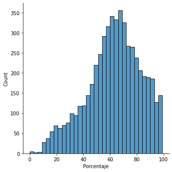

```python
sns.displot(data['Porcentaje'] )
```

Se puede observar que existe asimetría hacia la izquierda y algunos picos. Voy a calcular la asimetría y curtosis de esta variable.

```python
print('Asimetria: %f' % data['Porcentaje'].skew())
print('Curtosis: %f' % data['Porcentaje'].kurt())
```

```
Asimetria: -0.429755
Curtosis: -0.245881
```

Ambos índices son negativos, por lo que se demuestra que es asimétrica a la izquierda. El índice de curtosis es negativo por lo que es platicúrtica y hay una menor concentración de los datos en torno a la media.

#### Análisis con variables categóricas

Voy a coger únicamente los datos de tipo object, ya que esas son mis variables categóricas.

```python
list(set(data.dtypes.tolist()))
```

```
[dtype('int64'), dtype('O')]
```

```python
data_num = data.select_dtypes(include = ['object'])
data_num.head()
```

|  | Periodo | Date | AirportName | City | State | Pais_Subdivision | Country | Geography |
| --- | --- | --- | --- | --- | --- | --- | --- | --- |
| 0 | Daily | 2020-07-05 | Kingsford Smith | Sydney | New South Wales | AU | Australia | POLYGON((151.164354085922 -33.9301772341877, 1... |
| 1 | Daily | 2020-05-28 | Kingsford Smith | Sydney | New South Wales | AU | Australia | POLYGON((151.164354085922 -33.9301772341877, 1... |
| 2 | Daily | 2020-05-07 | Kingsford Smith | Sydney | New South Wales | AU | Australia | POLYGON((151.164354085922 -33.9301772341877, 1... |
| 3 | Daily | 2020-06-24 | Kingsford Smith | Sydney | New South Wales | AU | Australia | POLYGON((151.164354085922 -33.9301772341877, 1... |
| 4 | Daily | 2020-08-05 | Kingsford Smith | Sydney | New South Wales | AU | Australia | POLYGON((151.164354085922 -33.9301772341877, 1... |

Diagrama de cajas:

[figure not shown]

```python
datos_grafico = pd.concat([data['Porcentaje'], data['Country']], axis = 1 )
f, ax = plt.subplots(figsize=(8,6))
fig = sns.boxplot( x = Country, y = 'Porcentaje', data = datos_grafico)
```

Voy a hacer un boxplot observando como se mueve en el tiempo. Para ello voy a añadir otra columna que me muestre los meses utilizando la columna existente 'Date' que me da el día, mes y año.

```python
# Separar date:

## Para ello primero creo una funcion lambda de tal forma que me separe lo que quiera por comas.

funcion = lambda x: pd.Series([i for i in reversed(x.split('-'))])

    ## A continuacion aplico la funcion lambda a la columna de Date. Es decir, va a dividir la
    ## columna Date por los guiones.

separacion = data['Date'].apply(funcion)

separacion.rename(columns={0:'Day',1:'Month',2:'Year'},inplace=True)
print (separacion)

data['Month'] = separacion['Month']
data['Month']
data
```

```
     Day Month  Year
0     05    07  2020
1     28    05  2020
2     07    05  2020
3     24    06  2020
4     05    08  2020
...   ..   ...   ...
5931  15    06  2020
5932  15    10  2020
5933  01    04  2020
5934  12    05  2020
5935  11    10  2020

[5402 rows x 3 columns]
```

|  | Periodo | Date | AirportName | Porcentaje | City | State | Pais_Subdivision | Country | Geography | Month |
| --- | --- | --- | --- | --- | --- | --- | --- | --- | --- | --- |
| 0 | Daily | 2020-07-05 | Kingsford Smith | 52 | Sydney | New South Wales | AU | Australia | POLYGON((151.164354085922 -33.9301772341877, 1... | 07 |
| 1 | Daily | 2020-05-28 | Kingsford Smith | 61 | Sydney | New South Wales | AU | Australia | POLYGON((151.164354085922 -33.9301772341877, 1... | 05 |
| 2 | Daily | 2020-05-07 | Kingsford Smith | 62 | Sydney | New South Wales | AU | Australia | POLYGON((151.164354085922 -33.9301772341877, 1... | 05 |
| 3 | Daily | 2020-06-24 | Kingsford Smith | 58 | Sydney | New South Wales | AU | Australia | POLYGON((151.164354085922 -33.9301772341877, 1... | 06 |
| 4 | Daily | 2020-08-05 | Kingsford Smith | 20 | Sydney | New South Wales | AU | Australia | POLYGON((151.164354085922 -33.9301772341877, 1... | 08 |
| ... | ... | ... | ... | ... | ... | ... | ... | ... | ... | ... |
| 5931 | Daily | 2020-06-15 | Seattle-Tacoma International | 64 | SeaTac | Washington | US-WA | United States of America (the) | POLYGON((-122.297594547272 47.434474106872, -1... | 06 |
| 5932 | Daily | 2020-10-15 | Seattle-Tacoma International | 74 | SeaTac | Washington | US-WA | United States of America (the) | POLYGON((-122.297594547272 47.434474106872, -1... | 10 |
| 5933 | Daily | 2020-04-01 | Seattle-Tacoma International | 65 | SeaTac | Washington | US-WA | United States of America (the) | POLYGON((-122.297594547272 47.434474106872, -1... | 04 |
| 5934 | Daily | 2020-05-12 | Seattle-Tacoma International | 65 | SeaTac | Washington | US-WA | United States of America (the) | POLYGON((-122.297594547272 47.434474106872, -1... | 05 |
| 5935 | Daily | 2020-10-11 | Seattle-Tacoma International | 57 | SeaTac | Washington | US-WA | United States of America (the) | POLYGON((-122.297594547272 47.434474106872, -1... | 10 |

5402 rows × 10 columns

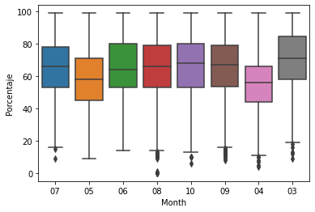

```python
datos_grafico = pd.concat([data['Porcentaje'], data['Month']], axis = 1 )

fig = sns.boxplot( x = 'Month', y = 'Porcentaje', data = datos_grafico)
```

Diagrama de barras:

Voy a realizar un diagrama de barras entre mi variable 'Porcentaje' con la variable 'Country' de tal forma que me muestre la el porcentaje de vuelos según el país.

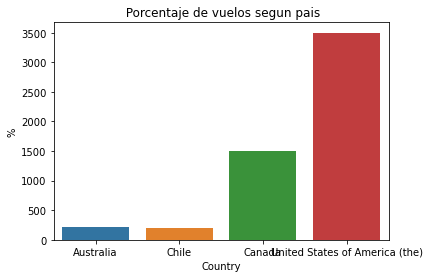

```
Porcentaje de vuelos en Australia  3.89 %
Porcentaje de vuelos en Chile  3.61 %
Porcentaje de vuelos en Canada  27.69 %
Porcentaje de vuelos en USA  64.81 %
```

```python
sns.countplot(x='Country',data=data)
plt.xlabel("Country")
plt.ylabel("%")
plt.title(" Porcentaje de vuelos segun pais")
plt.show()
plt.show()
print('Porcentaje de vuelos en Australia ',round(len(data[data['Country']=='Australia'])/len(data['Country'])*100,2),"%")
print('Porcentaje de vuelos en Chile ',round(len(data[data['Country']=='Chile'])/len(data['Country'])*100,2),"%")
print('Porcentaje de vuelos en Canada ',round(len(data[data['Country']=='Canada'])/len(data['Country'])*100,2),"%")
print('Porcentaje de vuelos en USA ',round(len(data[data['Country']=='United States of America (the)'])/len(data['Country'])*100,2),"%")
```

Se puede observar que el país con más número de vuelos es Estados Unidos (64.81%) seguido de Canadá (27.69%).

Voy a realizar un diagrama de barras pero esta vez con la variable 'Month', de tal forma que me muestre el porcentaje de vuelos en función del mes en el que se producen.

```python
np.unique(data['Month'])
```

```
array(['03', '04', '05', '06', '07', '08', '09', '10'], dtype=object)
```

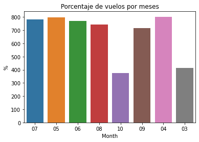

[output not shown]

```python
sns.countplot(x='Month',data=data)
plt.xlabel("Month")
plt.ylabel("%")
plt.title(" Porcentaje de vuelos por meses ")
plt.show()
plt.show()
print('Porcentaje de vuelos en Marzo ',round(len(data[data['Month']=='03'])/len(data['Month'])*100,2),"%")
print('Porcentaje de vuelos en Abril ',round(len(data[data['Month']=='04'])/len(data['Month'])*100,2),"%")
print('Porcentaje de vuelos en Mayo ',round(len(data[data['Month']=='05'])/len(data['Month'])*100,2),"%")
print('Porcentaje de vuelos en Junio ',round(len(data[data['Month']=='06'])/len(data['Month'])*100,2),"%")
print('Porcentaje de vuelos en Julio ',round(len(data[data['Month']=='07'])/len(data['Month'])*100,2),"%")
print('Porcentaje de vuelos en Agosto ',round(len(data[data['Month']=='08'])/len(data['Month'])*100,2),"%")
print('Porcentaje de vuelos en Septiembre ',round(len(data[data['Month']=='09'])/len(data['Month'])*100,2),"%")
print('Porcentaje de vuelos en Octubre ',round(len(data[data['Month']==' 10'])/len(data['Month'])*100,2),"%")
```

El mes en el que se produjeron más vuelos fue en Abril con un 14.86% del total.

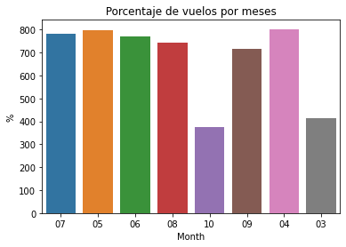

```python
sns.countplot(x='Month',data=data)
plt.xlabel("Month")
plt.ylabel("%")
plt.title(" Porcentaje de vuelos por meses ")
plt.show()
plt.show()
```

A continuación, voy a realizar un gráfico de barras que me de información acerca de los vuelos que se producen en función del país y del mes.

[figure not shown]

```python
data_USA = data[(data["Country"] == 'United States of America (the)')]
data_Canada = data[(data["Country"] == 'Canada')]

mes = data['Month'].unique()
USA = data_USA['Country'].count()
Canada = data_Canada['Country'].count()

data_plot = pd.DataFrame({'United States of America (the)': USA,
                    'Canada': Canada},
                       index=mes)
data_plot.plot(kind='bar')
```

[figure not shown]

```python
data_Australia = data[(data["Country"] == 'Australia')]
data_Chile = data[(data["Country"] == 'Chile')]

mes = data['Month'].unique()
Australia = data_AU['Country'].count()
Chile = data_Chile['Country'].count()

data_plot = pd.DataFrame({'Australia': Australia,
                    'Chile': Chile},
                       index=mes)
data_plot.plot(kind='bar')
```

```python
np.unique(data['AirportName'])
```

```
array(['Boston Logan International ', 'Calgary International',
       'Charlotte Douglas International', 'Chicago OHare International',
       'Dallas/Fort Worth International ',
       'Daniel K. Inouye International ', 'Denver International',
       'Detroit Metropolitan Wayne County ', 'Edmonton International',
       'Halifax International', 'Hamilton International',
       'Hartsfield-Jackson Atlanta International ',
       'John F. Kennedy International', 'Kingsford Smith', 'LaGuardia',
       'Los Angeles International', 'McCarran International',
       'Miami International ', 'Montreal Mirabel', 'Montreal Trudeau',
       'Newark Liberty International ', 'San Francisco International',
       'Santiago International Airport', 'Seattle-Tacoma International ',
       'Toronto Pearson', 'Vancouver International',
       'Washington Dulles International ', 'Winnipeg International'],
      dtype=object)
```

Gráfico de tartas:

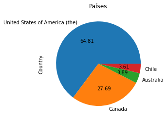

```python
grafico = data['Country'].value_counts().plot(kind = 'pie',autopct = '%.2f', title = 'Países')
```

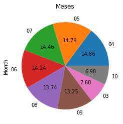

```python
grafico = data['Month'].value_counts().plot(kind = 'pie',autopct = '%.2f', title = 'Meses')
```

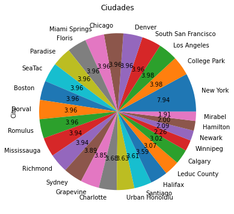

```python
grafico = data['City'].value_counts().plot(kind = 'pie',autopct = '%.2f',figsize=(6,6), title = 'Ciudades')
```

#### Detectar Outliers

Voy a realizar primero un boxplot para mi variable 'Porcentaje'.

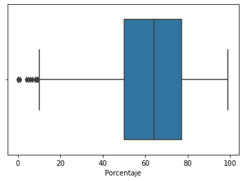

```python
sns.boxplot(x=data['Porcentaje'])
```

```python
Q1 = data.quantile(0.25)
Q3 = data.quantile(0.75)
IQR = Q3-Q1
print(IQR)

    #Para eliminar los outliers.
```

```
Porcentaje    27.0
dtype: float64
```

A continuación voy a eliminar los outliers.

```python
data = data[~((data < (Q1-1.5 * IQR)) |(data > (Q3 + 1.5 * IQR))).any(axis=1)]
data.shape
```

```
(5385, 10)
```

Habían 17 filas que eran outliers por lo que se han eliminado un total de 17 outliers.

### Concluisones

Mediante este análisis exploratorio he realizado una limpieza de la base de datos para no tener problemas a la hora de analizar en caso de que existiesen valores NaN o algunos valores atípicos, al igual que he eliminado columnas que no eran significativas para este análisis.

La variable a explicar en este caso y la que más interesa es el 'Porcentaje' que recoge la proporción de viajes que se realizan para cada fecha. Al realizar el estudio de la normalidad de esta variable se ha observado que tiene asimetría hacia la izquierda y algunos picos, siendo su curtosis también negativa, lo cual nos dice que es platicúrtica y hay una menor concentración de los datos en torno a la media.

A la hora de analizar las variables categóricas, se han realizado diagramas de cajas, de barras y de tartas. En los diagramas de barras se ha calculado y representado el porcentaje de vuelos según el país, siendo EEUU el país con mayor número de vuelos, y el porcentaje de vuelos según el mes, siendo abril el mes con mayor afluencia de vuelos.

Se ha observado que la variable en cuestión presenta filas que son outliers. Se han mostrado un total de 17 outliers.

En el diagrama de tartas realizado para las ciudades se puede observar que la ciudad que recibe un mayor número de vuelos es Nueva York con un 7.94% del total, lo cual demuestra que el país que ha recibido más vuelos durante el covid es EEUU.

### Referencias:

A. (2019, 14 julio). Analisis exploratorio de datos con Python. Kaggle. https://www.kaggle.com/abonaplata/analisis-exploratorio-de-datos-con-python

E. (2017, 20 enero). Detailed exploratory data analysis with python. Kaggle. https://www.kaggle.com/ekami66/detailed-exploratory-data-analysis-with-python

H. (2020, 26 agosto). https://towardsdatascience.com/exploratory-data-analysis-tutorial-in-python-15602b417445. Kaggle. https://www.kaggle.com/harshsdw/heart-failure-eda-and-catboost-classification

Prabhu, T. N. (2019, 11 agosto). Exploratory data analysis in Python. - Towards Data Science. Medium. https://towardsdatascience.com/exploratory-data-analysis-in-python-c9a77dfa39ce